# hw4gizem

4th Dataset

In the fourth data set, there are more than 20 features. The dataset is about frogs. The target integer can be selected from the dataset. It is metadata, there are only features there is no specific target. The target is chosen as Genus. Also recordID is chosen for stochastic gradient boosting method, since recordID had numerical data in the column which can be used for error calculations. Also class imbalance is done on this data by editing the raw data.

4th Dataset is prepared.There was no test data, therefore it is created by using the coding below.

```r
#4th dataset

anurandata<- read.csv(file="C:/Users/Gizem/Desktop/hw4gz/Frogs_MFCCs.csv", header=TRUE, sep=",")

## 75% of the sample size
smp_sizefrog <- floor(0.75 * nrow(anurandata))

## set the seed to make your partition reproducible
set.seed(123)
train_indfrog <- sample(seq_len(nrow(anurandata)), size = smp_sizefrog)

trainfrog <- anurandata[train_indfrog, ]
testfrog <- anurandata[-train_indfrog, ]
```

Decision Tree is done for 4th dataset

```
## [1] NA
```

```
## [1] NA
```

```
## [1] NA
```

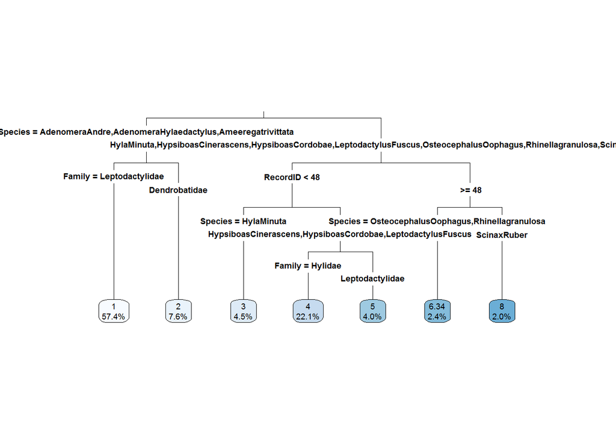

```
## [1] NA
```

```
## [1] NA
```

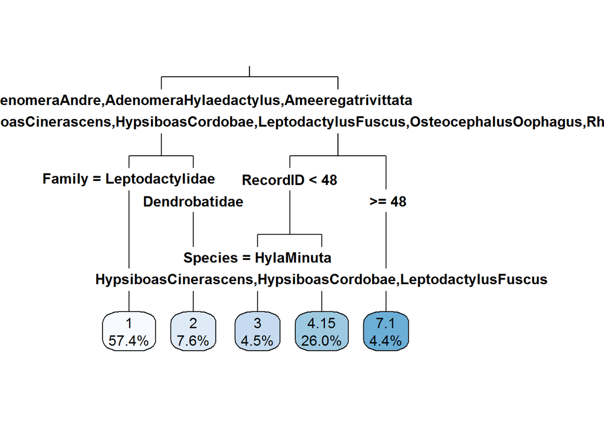

```
## [1] NA
```

```r
# Decision Tree
require(rpart.plot)
for (i in 1:3){
  set.seed(124)
  desiciontree1 <- rpart(Genus~., data=trainfrog, control=rpart.control(minbucket = 2+i,cp=0.005*i),method = "anova")

  rpart.plot(desiciontree1,type = 3,digits = 3,fallen.leaves = TRUE)
  #Predictions
  pred1train<-predict(desiciontree1,trainfrog)
  #Mean Absolute Error for train data

  MeanAbsError<-function(actual,predicted){mean(abs(actual - predicted))
  }
  pred1test<-predict(desiciontree1,testfrog)

  #mean absolute error for train data is found as
  print(MeanAbsError(trainfrog$Genus,pred1train))
  #mean absolute error for test data is found as
  print(MeanAbsError(testfrog$Genus,pred1test))
}
```

[output not shown]

```r
print(desiciontree1)
```

```
## n= 5396
##
## node), split, n, deviance, yval
##       * denotes terminal node
##
##  1) root 5396 16093.8700 2.258340
##    2) Species=AdenomeraAndre,AdenomeraHylaedactylus,Ameeregatrivittata 3508   363.6123 1.117446
##      4) Family=Leptodactylidae 3096     0.0000 1.000000 *
##      5) Family=Dendrobatidae 412     0.0000 2.000000 *
##    3) Species=HylaMinuta,HypsiboasCinerascens,HypsiboasCordobae,LeptodactylusFuscus,OsteocephalusOophagus,Rhinellagranulosa,ScinaxRuber 1888  2679.9810 4.378178
##      6) RecordID< 47.5 1648   456.4897 3.982403
##       12) Species=HylaMinuta 243     0.0000 3.000000 *
##       13) Species=HypsiboasCinerascens,HypsiboasCordobae,LeptodactylusFuscus 1405   181.4050 4.152313 *
##      7) RecordID>=47.5 240   192.7958 7.095833 *
```

```r
print("cp values for error rates")
```

```
## [1] "cp values for error rates"
```

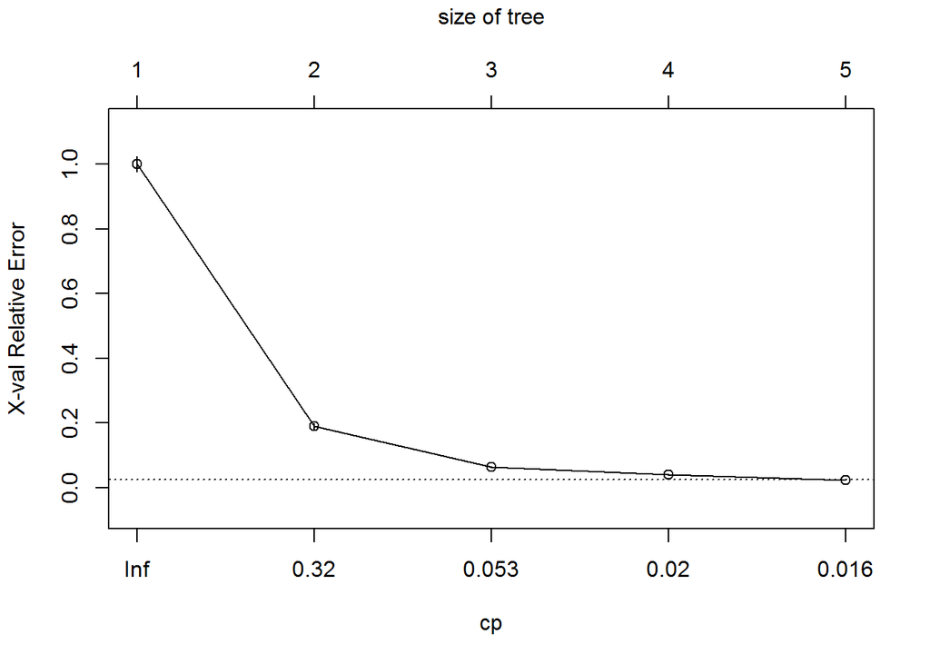

```r
plotcp(desiciontree1)
```

Stochastic Gradient Boosting with Genus estimation

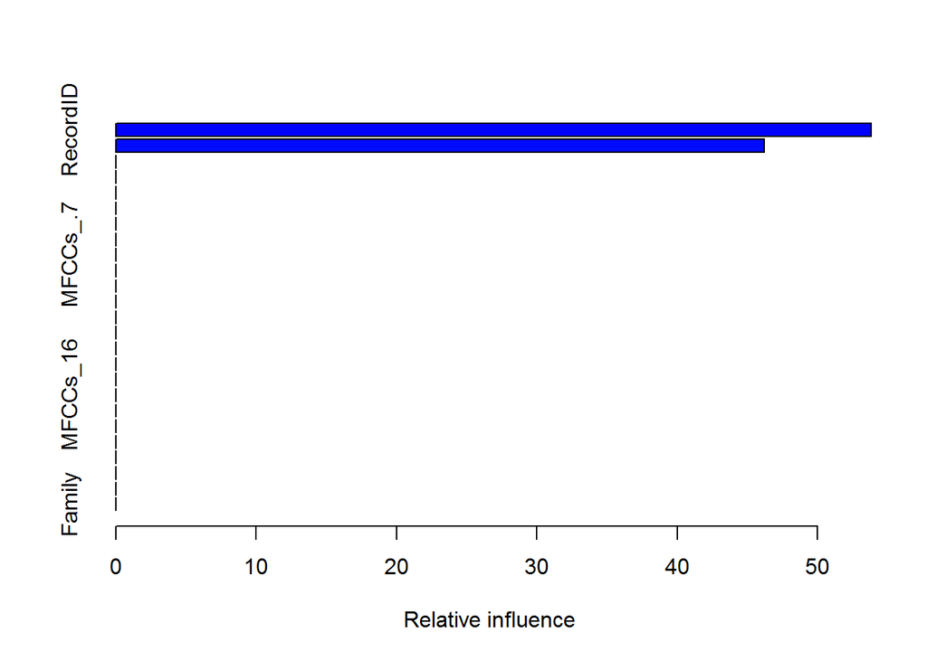

```
##               var  rel.inf
## RecordID RecordID 53.80637
## Species   Species 46.19363
## MFCCs_.1 MFCCs_.1  0.00000
## MFCCs_.2 MFCCs_.2  0.00000
## MFCCs_.3 MFCCs_.3  0.00000
## MFCCs_.4 MFCCs_.4  0.00000
## MFCCs_.5 MFCCs_.5  0.00000
## MFCCs_.6 MFCCs_.6  0.00000
## MFCCs_.7 MFCCs_.7  0.00000
## MFCCs_.8 MFCCs_.8  0.00000
## MFCCs_.9 MFCCs_.9  0.00000
## MFCCs_10 MFCCs_10  0.00000
## MFCCs_11 MFCCs_11  0.00000
## MFCCs_12 MFCCs_12  0.00000
## MFCCs_13 MFCCs_13  0.00000
## MFCCs_14 MFCCs_14  0.00000
## MFCCs_15 MFCCs_15  0.00000
## MFCCs_16 MFCCs_16  0.00000
## MFCCs_17 MFCCs_17  0.00000
## MFCCs_18 MFCCs_18  0.00000
## MFCCs_19 MFCCs_19  0.00000
## MFCCs_20 MFCCs_20  0.00000
## MFCCs_21 MFCCs_21  0.00000
## MFCCs_22 MFCCs_22  0.00000
## Family     Family  0.00000
```

```r
#Stochastic Gradient Boosting with Genus estimation
library(caret)
require(gbm)

set.seed(124)

boosting1<-gbm(Genus~.,data = trainfrog,distribution="gaussian",cv.folds = 3)
summary(boosting1)
```

```r
preddata1gbm<-as.data.frame(predict(boosting1,n.trees = 100))
resultgbm<-cbind(trainfrog$Genus, preddata1gbm)
```

Stochastic Gradient Boosting with recordID estimation

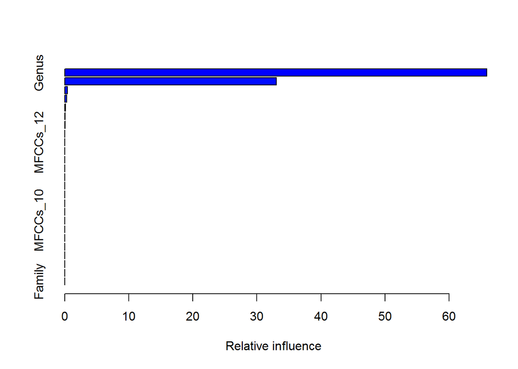

```
##               var     rel.inf
## Genus       Genus 65.88954652
## Species   Species 33.05156945
## MFCCs_.3 MFCCs_.3  0.45631125
## MFCCs_13 MFCCs_13  0.28959055
## MFCCs_19 MFCCs_19  0.14417169
## MFCCs_16 MFCCs_16  0.09365816
## MFCCs_15 MFCCs_15  0.04098824
## MFCCs_11 MFCCs_11  0.02186059
## MFCCs_12 MFCCs_12  0.01230354
## MFCCs_.1 MFCCs_.1  0.00000000
## MFCCs_.2 MFCCs_.2  0.00000000
## MFCCs_.4 MFCCs_.4  0.00000000
## MFCCs_.5 MFCCs_.5  0.00000000
## MFCCs_.6 MFCCs_.6  0.00000000
## MFCCs_.7 MFCCs_.7  0.00000000
## MFCCs_.8 MFCCs_.8  0.00000000
## MFCCs_.9 MFCCs_.9  0.00000000
## MFCCs_10 MFCCs_10  0.00000000
## MFCCs_14 MFCCs_14  0.00000000
## MFCCs_17 MFCCs_17  0.00000000
## MFCCs_18 MFCCs_18  0.00000000
## MFCCs_20 MFCCs_20  0.00000000
## MFCCs_21 MFCCs_21  0.00000000
## MFCCs_22 MFCCs_22  0.00000000
## Family     Family  0.00000000
```

```r
#Stochastic Gradient Boosting with recordID estimation
library(caret)
require(gbm)

set.seed(124)

boosting1<-gbm(RecordID~.,data = trainfrog,distribution="gaussian",cv.folds = 3)
summary(boosting1)
```

```r
preddata1gbm<-as.data.frame(predict(boosting1,n.trees = 100))
resultgbm<-cbind(trainfrog$RecordID, preddata1gbm)
```

```r
errortrain=sum((resultgbm[,2] - mean(resultgbm[,2]))^2) / sum((resultgbm[,1] - mean(resultgbm[,1]))^2)
#coefficient of determination is found as for train data
print(errortrain)
```

```
## [1] 0.9202024
```

```r
preddata1gbm<-as.data.frame(predict(boosting1,testfrog, n.trees = 100))
resultgbm<-cbind(testfrog$RecordID, preddata1gbm)
```

```r
errortest=sum((resultgbm[,2] - mean(resultgbm[,2]))^2) / sum((resultgbm[,1] - mean(resultgbm[,1]))^2)
#coefficient of determination is found as for test data
print(errortest)
```

```
## [1] 0.9193708
```

Support Vector Machines with Genus